This Notebook is based on the official documentation at [link](https://cran.r-project.org/)

To see more of these notebooks [link](https://jmsevillam.github.io/R_basics/)

# Simple manipulations; numbers and vectors

For languages such as `R`, it is natural to have array-vector like structures where data is saved.

We are going to explore them and some of the possible operations.

## Vectors and Assignment

We just saw how a collection of things can be done, but let us explore more on that direction.

We may create a collection of numbers, for example

```r
x=c(1,2,3,4)
x
```

1. 1

2. 2

3. 3

4. 4

Look that all of them are numbers, but, there are different *kinds* of numbers while programming, and that is a particular one, let us see that,

we can ask which *kind* of data `x` is

```r
typeof(x)
```

'double'

`double` means that it is a number that can take decimal values, but if we initialize `x` differently.

When we do operations as the following, the precedent value of x, gets replaced by the new assignation operation!

```r
x = 1:4
x
```

1. 1

2. 2

3. 3

4. 4

It looks exactly the same as before!, but now it has a different data type

```r
typeof(x)
```

'integer'

So the components of `x` are all of them integers, so the coputer will understand they differently.

We also want to have words sometimes, but look

```r
x=c("Word",1,2,3.2)
x
```

1. 'Word'

2. '1'

3. '2'

4. '3.2'

Look that now we don't get `1` but `'1'` instead, that is because now we don't have the number 1, but the character "1" itself.

```r
typeof(x)
```

'character'

Let us see some of the differences

```r
x=c(1,2,3)
y=c("1","2","3")
```

```r
print(typeof(x))
print(typeof(y))
```

```
[1] "double"
[1] "character"
```

```r
x*2 # Multiplication of all the components!
```

1. 2

2. 4

3. 6

```r
y*2 # It cannot do the multiplication because they are characters
```

```
Error in y * 2: argumento no-numérico para operador binario
Traceback:
```

We will explore these characters operations later.

#### More on assignation

So far, we have assign things with `=`, but there are more ways to do that

```r
x=c(1,2,3)
x
```

1. 1

2. 2

3. 3

```r
x<-c(1,2,3)
x
```

1. 1

2. 2

3. 3

```r
c(1,2,3)->x
x
```

1. 1

2. 2

3. 3

These are the most used.

### Numerical operations (Vectors)

for instance, some simple transformations are

```r
x=seq(1,10,0.1)
x
```

1. 1

2. 1.1

3. 1.2

4. 1.3

5. 1.4

6. 1.5

7. 1.6

8. 1.7

9. 1.8

10. 1.9

11. 2

12. 2.1

13. 2.2

14. 2.3

15. 2.4

16. 2.5

17. 2.6

18. 2.7

19. 2.8

20. 2.9

21. 3

22. 3.1

23. 3.2

24. 3.3

25. 3.4

26. 3.5

27. 3.6

28. 3.7

29. 3.8

30. 3.9

31. 4

32. 4.1

33. 4.2

34. 4.3

35. 4.4

36. 4.5

37. 4.6

38. 4.7

39. 4.8

40. 4.9

41. 5

42. 5.1

43. 5.2

44. 5.3

45. 5.4

46. 5.5

47. 5.6

48. 5.7

49. 5.8

50. 5.9

51. 6

52. 6.1

53. 6.2

54. 6.3

55. 6.4

56. 6.5

57. 6.6

58. 6.7

59. 6.8

60. 6.9

61. 7

62. 7.1

63. 7.2

64. 7.3

65. 7.4

66. 7.5

67. 7.6

68. 7.7

69. 7.8

70. 7.9

71. 8

72. 8.1

73. 8.2

74. 8.3

75. 8.4

76. 8.5

77. 8.6

78. 8.7

79. 8.8

80. 8.9

81. 9

82. 9.1

83. 9.2

84. 9.3

85. 9.4

86. 9.5

87. 9.6

88. 9.7

89. 9.8

90. 9.9

91. 10

We can create a vector from another, which is the result of an element-wise operation, so

```r
y=1/x
y
```

1. 1

2. 0.909090909090909

3. 0.833333333333333

4. 0.769230769230769

5. 0.714285714285714

6. 0.666666666666667

7. 0.625

8. 0.588235294117647

9. 0.555555555555556

10. 0.526315789473684

11. 0.5

12. 0.476190476190476

13. 0.454545454545455

14. 0.434782608695652

15. 0.416666666666667

16. 0.4

17. 0.384615384615385

18. 0.37037037037037

19. 0.357142857142857

20. 0.344827586206897

21. 0.333333333333333

22. 0.32258064516129

23. 0.3125

24. 0.303030303030303

25. 0.294117647058823

26. 0.285714285714286

27. 0.277777777777778

28. 0.27027027027027

29. 0.263157894736842

30. 0.256410256410256

31. 0.25

32. 0.24390243902439

33. 0.238095238095238

34. 0.232558139534884

35. 0.227272727272727

36. 0.222222222222222

37. 0.217391304347826

38. 0.212765957446809

39. 0.208333333333333

40. 0.204081632653061

41. 0.2

42. 0.196078431372549

43. 0.192307692307692

44. 0.188679245283019

45. 0.185185185185185

46. 0.181818181818182

47. 0.178571428571429

48. 0.175438596491228

49. 0.172413793103448

50. 0.169491525423729

51. 0.166666666666667

52. 0.163934426229508

53. 0.161290322580645

54. 0.158730158730159

55. 0.15625

56. 0.153846153846154

57. 0.151515151515151

58. 0.149253731343284

59. 0.147058823529412

60. 0.144927536231884

61. 0.142857142857143

62. 0.140845070422535

63. 0.138888888888889

64. 0.136986301369863

65. 0.135135135135135

66. 0.133333333333333

67. 0.131578947368421

68. 0.12987012987013

69. 0.128205128205128

70. 0.126582278481013

71. 0.125

72. 0.123456790123457

73. 0.121951219512195

74. 0.120481927710843

75. 0.119047619047619

76. 0.117647058823529

77. 0.116279069767442

78. 0.114942528735632

79. 0.113636363636364

80. 0.112359550561798

81. 0.111111111111111

82. 0.10989010989011

83. 0.108695652173913

84. 0.10752688172043

85. 0.106382978723404

86. 0.105263157894737

87. 0.104166666666667

88. 0.103092783505155

89. 0.102040816326531

90. 0.101010101010101

91. 0.1

And we can plot the two vectors, taking on the $x$ axis one and on the $y$ axis the other, such that

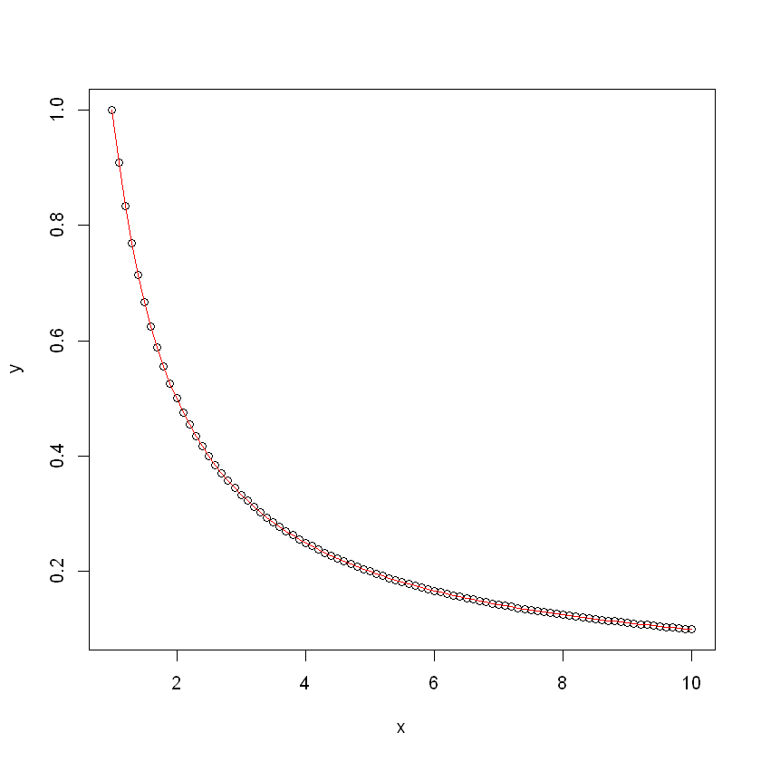

```r
plot(x,y)
lines(x,y,col="red")
```

We can create a vector from a set of other vectors using the same function previously described, in particular we can use the same one (but not necessarily), let us try this example out,

```r
x1=seq(1,5)
x2=seq(7,8.6,0.5)

print(x1)
print(x2)

y=c(x1,x2)
print(y)
```

```
[1] 1 2 3 4 5
[1] 7.0 7.5 8.0 8.5
[1] 1.0 2.0 3.0 4.0 5.0 7.0 7.5 8.0 8.5
```

So that, we get a uniformly formated vector (All of them are double), resulting of the concatenation of the two vectors

Let us consider a particularity of `R` regarding to the operations, so first, let us take a vector `y` with length $n$ times the length of `x`. To guarantee that, we will construct it with a collection of several `x`s, such that

```r
x=seq(0,1,0.1)
y=c(x,x,x)
y
```

1. 0

2. 0.1

3. 0.2

4. 0.3

5. 0.4

6. 0.5

7. 0.6

8. 0.7

9. 0.8

10. 0.9

11. 1

12. 0

13. 0.1

14. 0.2

15. 0.3

16. 0.4

17. 0.5

18. 0.6

19. 0.7

20. 0.8

21. 0.9

22. 1

23. 0

24. 0.1

25. 0.2

26. 0.3

27. 0.4

28. 0.5

29. 0.6

30. 0.7

31. 0.8

32. 0.9

33. 1

So, what we get is a *repetition* of the vector `x`

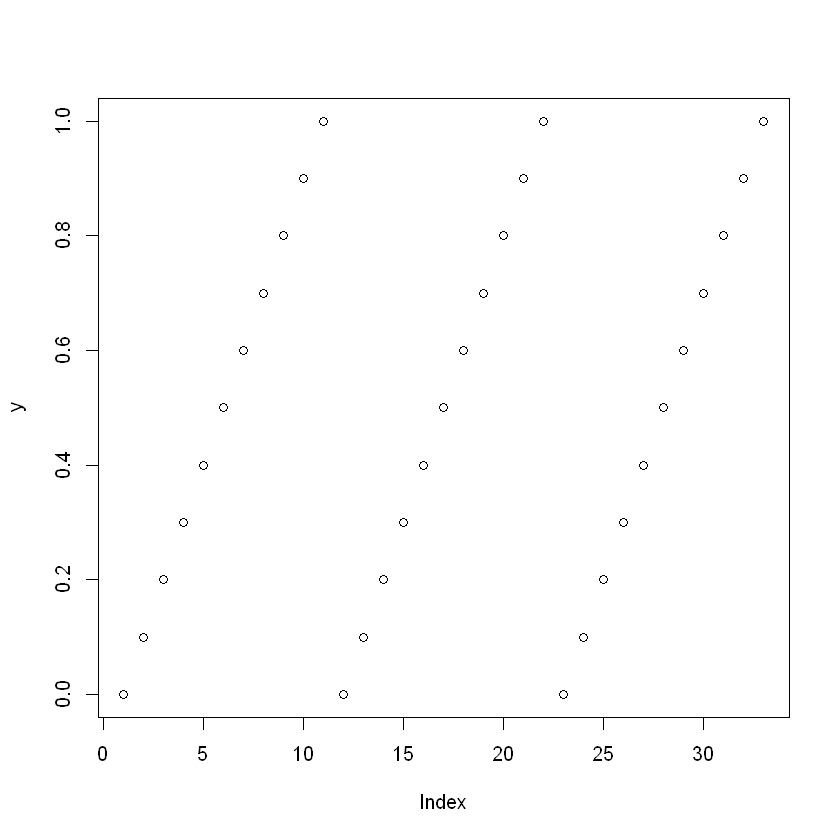

```r
plot(y)
```

if we sum them, we get the following

```r
x+y
```

1. 0

2. 0.2

3. 0.4

4. 0.6

5. 0.8

6. 1

7. 1.2

8. 1.4

9. 1.6

10. 1.8

11. 2

12. 0

13. 0.2

14. 0.4

15. 0.6

16. 0.8

17. 1

18. 1.2

19. 1.4

20. 1.6

21. 1.8

22. 2

23. 0

24. 0.2

25. 0.4

26. 0.6

27. 0.8

28. 1

29. 1.2

30. 1.4

31. 1.6

32. 1.8

33. 2

Can you guess how does it work?

### Some usefull commands

First, we have already use this, but the correct way to create a set-vector-array of data is with a `c` (Collection)

```r
x=c(1,2)
x
```

1. 1

2. 2

```r
y=c(1,2,3,4)
y
```

1. 1

2. 2

3. 3

4. 4

`R` supports element-wise operations

```r
2*x
```

1. 2

2. 4

The length of the vector

```r
length(x)
```

2

```r
length(y)
```

4

Very important, if one vector has a length $n$ times larger than other, they can be operated, the *small one* gets repeated as many times as needed.

```r
z=x+y
```

There are some build in functions, such as the sum of all the components of an vector

```r
sum(z)
```

16

Or the mean of the data

```r
mean(z)
```

4

we can substract the mean to each one of the components of a vector `z`

```r
(z-mean(z))
```

1. -2

2. 0

3. 0

4. 2

Another element-wise operation is the power, so, we can square each element.

```r
(z-mean(z))^2
```

1. 4

2. 0

3. 0

4. 4

The parenthesis will give us a guide of the order of the operations

```r
sum((z-mean(z))^2)
```

8

We can also compute quantities such as the variance $$\operatorname{var}(\mathbf{z})=\frac{1}{n-1}\sum_i (z_i-\mu){^2}$$ where $\mu$ is the mean of the data,

```r
sum((z-mean(z))^2)/(length(z)-1)
```

2.66666666666667

But this operation has also been implemented,

```r
var(z)
```

2.66666666666667

Let us try some others instructions

```r
x=c(7,3,8,4,6,9,0,1,12)
```

We can sort the values of a vector just by using

```r
sort(x)
```

1. 0

2. 1

3. 3

4. 4

5. 6

6. 7

7. 8

8. 9

9. 12

But, the values are not saved

```r
x
```

1. 7

2. 3

3. 8

4. 4

5. 6

6. 9

7. 0

8. 1

9. 12

If we want to save the sorted values, we have to do it explicitly

```r
x<-sort(x)
x
```

1. 0

2. 1

3. 3

4. 4

5. 6

6. 7

7. 8

8. 9

9. 12

The maximum or the minimum can be easily gotten by,

```r
print(max(x))
print(min(x))
```

```
[1] 12
[1] 0
```

Some mathematical functions can be also used,

```r
sqrt(z)
```

1. 1.4142135623731

2. 2

3. 2

4. 2.44948974278318

Even for complex numbers

```r
sqrt(z+1i)
```

1. 1.45534669022535+0.34356074972251i

2. 2.01532945515338+0.24809839340236i

3. 2.01532945515338+0.24809839340236i

4. 2.45792214383391+0.20342385589972i

```r
z
```

1. 2

2. 4

3. 4

4. 6

If we want, we can create random numbers, but we will explore this later with way more datail, let us create 1000 random uniformly distributed points,

```r
x=runif(1000)
```

So if we plot them

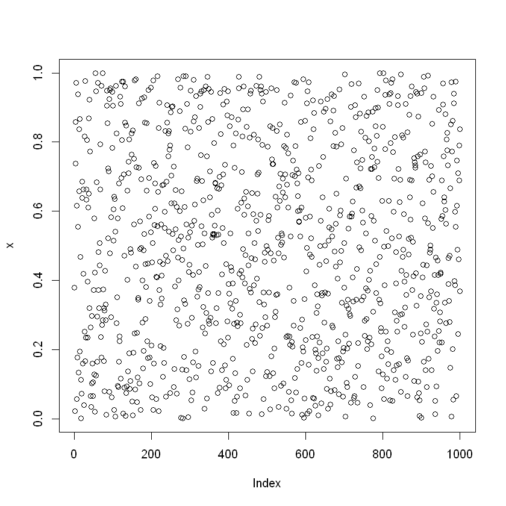

```r
plot(x)
```

To convince ourselves that they are really uniform, we can create a histogram

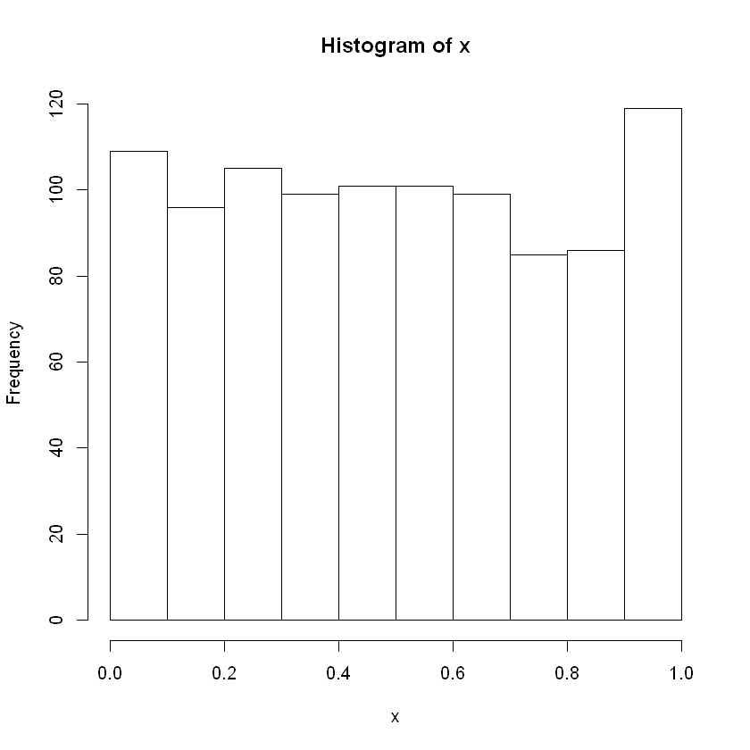

```r
hist(x)
```

As we have done before, we can apply some comparison operations for all the particular vector

```r
x=runif(100)
temp= x>0.5
temp
```

1. TRUE

2. FALSE

3. FALSE

4. FALSE

5. TRUE

6. TRUE

7. FALSE

8. FALSE

9. FALSE

10. TRUE

11. FALSE

12. FALSE

13. TRUE

14. TRUE

15. FALSE

16. FALSE

17. FALSE

18. TRUE

19. TRUE

20. TRUE

21. FALSE

22. TRUE

23. FALSE

24. FALSE

25. FALSE

26. FALSE

27. TRUE

28. TRUE

29. FALSE

30. TRUE

31. FALSE

32. FALSE

33. TRUE

34. TRUE

35. TRUE

36. TRUE

37. TRUE

38. TRUE

39. FALSE

40. FALSE

41. TRUE

42. TRUE

43. FALSE

44. TRUE

45. TRUE

46. FALSE

47. TRUE

48. FALSE

49. TRUE

50. FALSE

51. FALSE

52. TRUE

53. FALSE

54. FALSE

55. FALSE

56. TRUE

57. FALSE

58. TRUE

59. TRUE

60. TRUE

61. TRUE

62. TRUE

63. TRUE

64. TRUE

65. FALSE

66. FALSE

67. TRUE

68. TRUE

69. FALSE

70. TRUE

71. FALSE

72. FALSE

73. FALSE

74. TRUE

75. TRUE

76. TRUE

77. FALSE

78. TRUE

79. FALSE

80. FALSE

81. FALSE

82. TRUE

83. TRUE

84. TRUE

85. TRUE

86. FALSE

87. FALSE

88. TRUE

89. TRUE

90. TRUE

91. FALSE

92. TRUE

93. FALSE

94. FALSE

95. TRUE

96. TRUE

97. FALSE

98. FALSE

99. FALSE

100. TRUE

#### Indexing a vector

Sometimes, we are not interested on the complete vector but just a part of it, for example, if we want just until the 40th component,

```r
temp[1:40]
```

1. TRUE

2. FALSE

3. FALSE

4. FALSE

5. TRUE

6. TRUE

7. FALSE

8. FALSE

9. FALSE

10. TRUE

11. FALSE

12. FALSE

13. TRUE

14. TRUE

15. FALSE

16. FALSE

17. FALSE

18. TRUE

19. TRUE

20. TRUE

21. FALSE

22. TRUE

23. FALSE

24. FALSE

25. FALSE

26. FALSE

27. TRUE

28. TRUE

29. FALSE

30. TRUE

31. FALSE

32. FALSE

33. TRUE

34. TRUE

35. TRUE

36. TRUE

37. TRUE

38. TRUE

39. FALSE

40. FALSE

or just the first

```r
temp[1]
```

TRUE

Let us explore this better

```r
x=c(1,2,6,8,9,3,1)
```

The first is the number 1, which depending the language can be the 0 (`C++`, `python`) or 1 (`Julia`, `Matlab`)

```r
x[1]
```

1

```r
x[0]
```

```r
x[2]
```

2

Negative values are not natural, so try to see what is what it does

```r
print(x)
print(x[-1])
```

```
[1] 1 2 6 8 9 3 1
[1] 2 6 8 9 3 1
```

```r
print(x)
print(x[-2])
```

```
[1] 1 2 6 8 9 3 1
[1] 1 6 8 9 3 1
```

```r
print(x)
print(x[-3])
```

```
[1] 1 2 6 8 9 3 1
[1] 1 2 8 9 3 1
```

```r
x[3:5]
```

1. 6

2. 8

3. 9

```r
x[-(2:3)]
```

1. 1

2. 8

3. 9

4. 3

5. 1

```r
x
```

1. 1

2. 2

3. 6

4. 8

5. 9

6. 3

7. 1